# Germination Treatment Analysis

Grace McFarlane

2025-04-19

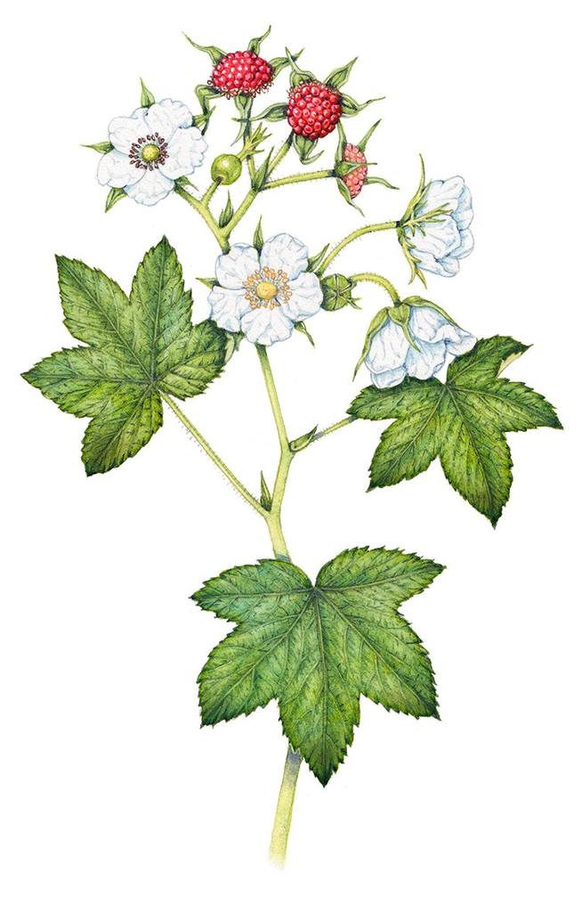

Rubus Parviflorus

## Methods

To assess germination rates across different seed pre-treatment methods, we compiled data from six populations under six experimental conditions: Control, Chemical (sulfuric acid bath), Room Temp. Water Bath, Hot Water Bath, Sandpaper Scarification, and Cold Stratification. Data were recorded as the proportion of seeds germinated per treatment in each population.

Data entry and cleaning were conducted in RStudio using the tidyverse package. Non-decimal values (e.g., “1/10”) were converted into decimal format for consistency. The data were then organized into a tidy data frame containing three columns: Population, Experiment, and Percent_Germinated.

Several visualizations were generated using ggplot2. A bar chart with facets was created to compare germination rates across treatments within each population. Boxplots were used to visualize overall treatment effects, and a heatmap helped identify patterns of germination success across the entire dataset.

```r
germ_data <- tribble(
  ~Population, ~Experiment, ~Percent_Germinated,
  "All", "Control", 0.15,
  "All", "Chemical", 0.19,
  "All", "Water Room", 0.006,
  "All", "Hot Bath", 0.006,
  "All", "Sand Paper", 0.08,
  "All", "Cold strat", 0,

  "ISRO", "Control", 0.08,
  "ISRO", "Chemical", 0.25,
  "ISRO", "Water Room", 0.04,
  "ISRO", "Hot Bath", 0.02,
  "ISRO", "Sand Paper", 0.08,
  "ISRO", "Cold strat", 0,

  "MCLA", "Control", 0.24,
  "MCLA", "Chemical", 0.18,
  "MCLA", "Water Room", 0.06,
  "MCLA", "Hot Bath", 0,
  "MCLA", "Sand Paper", 0.08,
  "MCLA", "Cold strat", 0,

  "EVER", "Control", 0.10,
  "EVER", "Chemical", 0.20,
  "EVER", "Water Room", 0.08,
  "EVER", "Hot Bath", 0,
  "EVER", "Sand Paper", 0.08,
  "EVER", "Cold strat", 0,

  "PBAY", "Control", 0,
  "PBAY", "Chemical", 0.1,
  "PBAY", "Water Room", 0,
  "PBAY", "Hot Bath", 0.1,
  "PBAY", "Sand Paper", 0,
  "PBAY", "Cold strat", 0.3,

  "HOME", "Control", 0,
  "HOME", "Chemical", 0,
  "HOME", "Water Room", 0,
  "HOME", "Hot Bath", 0,
  "HOME", "Sand Paper", 0,
  "HOME", "Cold strat", 0.5
)
```